# Neural networks

Aprendizaje Estadístico, Máster en Tecnologías de Análisis de Datos Masivos: Big Data. Profesor: Juan A. Botía (juanbot@um.es)

2024-12-04

# 1 Introduction

En esta sección, mostramos cómo ajustar redes neuronales. Usamos el paquete keras, que funciona como una interfaz para el paquete tensorflow, el cual a su vez se conecta con código Python eficiente. Este código es impresionantemente rápido, y el paquete está bien estructurado. Un buen complemento es el libro Deep Learning with R, de donde se ha adaptado la mayor parte de nuestro código.

Configurar keras en tu computadora puede ser un desafío. El sitio web del libro ofrece instrucciones detalladas paso a paso para hacerlo. Más información también se puede encontrar en Rstudio.

# 2 Single layer network

Comenzamos ajustando un modelo lineal básico para predecir el Salary en el conjunto de datos Hitters (322 ejemplos de jugadores de béisbol de las ligas mayores). Configuramos los datos y separamos un conjunto de entrenamiento y uno de prueba.

```r
library(ISLR2)
str(Hitters)
```

```
## 'data.frame':    322 obs. of  20 variables:
##  $ AtBat    : int  293 315 479 496 321 594 185 298 323 401 ...
##  $ Hits     : int  66 81 130 141 87 169 37 73 81 92 ...
##  $ HmRun    : int  1 7 18 20 10 4 1 0 6 17 ...
##  $ Runs     : int  30 24 66 65 39 74 23 24 26 49 ...
##  $ RBI      : int  29 38 72 78 42 51 8 24 32 66 ...
##  $ Walks    : int  14 39 76 37 30 35 21 7 8 65 ...
##  $ Years    : int  1 14 3 11 2 11 2 3 2 13 ...
##  $ CAtBat   : int  293 3449 1624 5628 396 4408 214 509 341 5206 ...
##  $ CHits    : int  66 835 457 1575 101 1133 42 108 86 1332 ...
##  $ CHmRun   : int  1 69 63 225 12 19 1 0 6 253 ...
##  $ CRuns    : int  30 321 224 828 48 501 30 41 32 784 ...
##  $ CRBI     : int  29 414 266 838 46 336 9 37 34 890 ...
##  $ CWalks   : int  14 375 263 354 33 194 24 12 8 866 ...
##  $ League   : Factor w/ 2 levels "A","N": 1 2 1 2 2 1 2 1 2 1 ...
##  $ Division : Factor w/ 2 levels "E","W": 1 2 2 1 1 2 1 2 2 1 ...
##  $ PutOuts  : int  446 632 880 200 805 282 76 121 143 0 ...
##  $ Assists  : int  33 43 82 11 40 421 127 283 290 0 ...
##  $ Errors   : int  20 10 14 3 4 25 7 9 19 0 ...
##  $ Salary   : num  NA 475 480 500 91.5 750 70 100 75 1100 ...
##  $ NewLeague: Factor w/ 2 levels "A","N": 1 2 1 2 2 1 1 1 2 1 ...
```

```r
Gitters <- na.omit(Hitters)
n <- nrow(Gitters)
set.seed (13)
ntest <- trunc(n / 3)
testid <- sample(1:n, ntest)
```

El modelo lineal debería ser familiar, pero lo presentamos de todos modos.

```r
lfit <- lm(Salary ~ ., data = Gitters[-testid, ])
lpred <- predict(lfit, Gitters[testid, ])
with(Gitters[testid , ], mean(abs(lpred - Salary)))
```

```
## [1] 254.6687
```

Observa el uso del comando with(): el primer argumento es un marco de datos, y el segundo es una expresión que puede referirse a elementos del marco de datos por su nombre. En este caso, el marco de datos corresponde a los datos de prueba, y la expresión calcula el error absoluto medio de predicción en estos datos.

A continuación, ajustamos el modelo de lasso usando glmnet. Dado que este paquete no utiliza fórmulas, primero creamos las variables x e y.

```r
x <- scale(model.matrix(Salary ~ . - 1, data = Gitters))
y <- Gitters$Salary
```

La primera línea llama a model.matrix(), que produce la misma matriz utilizada por lm() (el -1 omite el intercepto). Esta función convierte automáticamente los factores en variables ficticias. La función scale() estandariza la matriz para que cada columna tenga media cero y varianza uno.

```r
library(glmnet)
cvfit <- cv.glmnet(x[-testid , ], y[-testid], type.measure = "mae")
cpred <- predict(cvfit , x[testid , ], s = "lambda.min")
mean(abs(y[testid] - cpred))
```

```
## [1] 252.2994
```

Para ajustar la red neuronal, primero configuramos una estructura de modelo que describe la red.

```r
#install_tensorflow()
#library(tensorflow)
library(reticulate)
use_python("/Users/juanbot/.virtualenvs/r-tensorflow/bin/python3.10")
#install_tensorflow()
library(keras3)
modnn <- keras_model_sequential(input_shape = ncol(x)) %>%
  layer_dense(units = 50, activation = "relu") %>%
  layer_dropout(rate = 0.4) %>% layer_dense(units = 1)
```

Creamos un modelo básico llamado modnn y agregamos detalles sobre las capas sucesivas de forma secuencial, utilizando la función keras model sequential().

El operador de tubería %>% pasa el término anterior como primer argumento a la siguiente función y devuelve el resultado. Esto nos permite especificar las capas de una red neuronal de forma legible.

Ilustramos el uso del operador de tubería con un ejemplo sencillo. Anteriormente, creamos x usando el comando:

```r
x <- scale(model.matrix(Salary ~ . - 1, data = Gitters))
```

Primero hacemos una matriz y luego centramos cada una de las variables. Las expresiones compuestas como esta pueden ser difíciles de analizar. Podríamos haber obtenido el mismo resultado usando el operador de tubería:

```r
x <- model.matrix(Salary ~ . - 1, data = Gitters) %>% scale()
```

Usar el operador de tubería facilita seguir la secuencia de operaciones. Ahora volvemos a nuestra red neuronal.

[output not shown]

Finalmente, la capa de salida tiene solo una unidad sin función de activación, lo que indica que el modelo proporciona una salida cuantitativa única.

A continuación, agregamos detalles a modnn que controlan el algoritmo de ajuste. El algoritmo realiza un seguimiento del error absoluto medio en los datos de entrenamiento y, si se proporciona, en los datos de validación.

```r
modnn %>% compile(loss = "mse",
                   optimizer = optimizer_rmsprop(),
metrics = list("mean_absolute_error") )
```

En la línea anterior, el operador de tubería pasa modnn como primer argumento a compile(). La función compile() no cambia realmente el objeto R modnn, pero comunica estas especificaciones a la instancia correspondiente en Python de este modelo que se ha creado en el proceso.

Ahora ajustamos el modelo. Proporcionamos los datos de entrenamiento y dos parámetros de ajuste: épocas y tamaño del lote. Usar 32 para este último significa que, en cada paso de SGD, el algoritmo selecciona aleatoriamente 32 observaciones de entrenamiento para el cálculo del gradiente.

Una época equivale al número de pasos de SGD necesarios para procesar $n$ observaciones. Dado que el conjunto de entrenamiento tiene $n = 176$, una época equivale a $176/32 = 5.5$ pasos de SGD.

La función fit() tiene un argumento para datos de validación; estos datos no se usan en el ajuste, pero pueden usarse para rastrear el progreso del modelo (en este caso, informando el error absoluto medio). Aquí proporcionamos los datos de prueba para poder observar el error absoluto medio tanto de los datos de entrenamiento como de los datos de prueba a medida que avanzan las épocas. Para ver más opciones de ajuste, utiliza ?fit.keras.engine.training.Model.

```r
 history <- modnn %>% fit(x[-testid, ],
                          y[-testid],
                          epochs = 100,
                          batch_size = 32,
                          validation_data = list(x[testid,
                                                   ],y[testid]))
```

```
## 6/6 - 1s - 129ms/step - loss: 457386.9688 - mean_absolute_error: 534.0018 - val_loss: 556120.6250 - val_mean_absolute_error: 539.7305
## 6/6 - 0s - 14ms/step - loss: 456931.4688 - mean_absolute_error: 533.6491 - val_loss: 555633.0000 - val_mean_absolute_error: 539.4471
## 6/6 - 0s - 14ms/step - loss: 456359.2188 - mean_absolute_error: 533.3411 - val_loss: 555267.5000 - val_mean_absolute_error: 539.2194
## 6/6 - 0s - 14ms/step - loss: 456249.5000 - mean_absolute_error: 533.1050 - val_loss: 554898.0000 - val_mean_absolute_error: 538.9915
## 6/6 - 0s - 14ms/step - loss: 455946.0000 - mean_absolute_error: 532.9303 - val_loss: 554517.1250 - val_mean_absolute_error: 538.7549
## 6/6 - 0s - 14ms/step - loss: 455565.6250 - mean_absolute_error: 532.6588 - val_loss: 554153.5000 - val_mean_absolute_error: 538.5328
## 6/6 - 0s - 14ms/step - loss: 455224.0312 - mean_absolute_error: 532.5405 - val_loss: 553765.1875 - val_mean_absolute_error: 538.2940
## 6/6 - 0s - 14ms/step - loss: 454845.4688 - mean_absolute_error: 532.1671 - val_loss: 553378.3750 - val_mean_absolute_error: 538.0662
## 6/6 - 0s - 14ms/step - loss: 454674.7188 - mean_absolute_error: 532.0024 - val_loss: 553007.2500 - val_mean_absolute_error: 537.8452
## 6/6 - 0s - 14ms/step - loss: 454264.1875 - mean_absolute_error: 531.7618 - val_loss: 552607.6250 - val_mean_absolute_error: 537.6130
## 6/6 - 0s - 14ms/step - loss: 453944.4688 - mean_absolute_error: 531.5300 - val_loss: 552211.7500 - val_mean_absolute_error: 537.3749
## 6/6 - 0s - 14ms/step - loss: 453489.2812 - mean_absolute_error: 531.2618 - val_loss: 551804.6875 - val_mean_absolute_error: 537.1365
## 6/6 - 0s - 14ms/step - loss: 453215.8125 - mean_absolute_error: 531.0575 - val_loss: 551414.8750 - val_mean_absolute_error: 536.9008
## 6/6 - 0s - 14ms/step - loss: 452939.0938 - mean_absolute_error: 530.8168 - val_loss: 550997.8125 - val_mean_absolute_error: 536.6492
## 6/6 - 0s - 14ms/step - loss: 452547.5938 - mean_absolute_error: 530.5501 - val_loss: 550570.8750 - val_mean_absolute_error: 536.3975
## 6/6 - 0s - 14ms/step - loss: 452225.2812 - mean_absolute_error: 530.2237 - val_loss: 550112.0625 - val_mean_absolute_error: 536.1340
## 6/6 - 0s - 14ms/step - loss: 451509.4062 - mean_absolute_error: 529.9633 - val_loss: 549649.9375 - val_mean_absolute_error: 535.8700
## 6/6 - 0s - 14ms/step - loss: 451357.9062 - mean_absolute_error: 529.7559 - val_loss: 549229.4375 - val_mean_absolute_error: 535.6141
## 6/6 - 0s - 14ms/step - loss: 451179.9062 - mean_absolute_error: 529.4816 - val_loss: 548793.2500 - val_mean_absolute_error: 535.3605
## 6/6 - 0s - 14ms/step - loss: 450737.9062 - mean_absolute_error: 529.3511 - val_loss: 548333.6250 - val_mean_absolute_error: 535.0886
## 6/6 - 0s - 14ms/step - loss: 450394.3750 - mean_absolute_error: 528.9913 - val_loss: 547841.5625 - val_mean_absolute_error: 534.8038
## 6/6 - 0s - 15ms/step - loss: 449923.0000 - mean_absolute_error: 528.5946 - val_loss: 547366.6875 - val_mean_absolute_error: 534.5239
## 6/6 - 0s - 14ms/step - loss: 449310.4062 - mean_absolute_error: 528.3417 - val_loss: 546805.8125 - val_mean_absolute_error: 534.2096
## 6/6 - 0s - 14ms/step - loss: 449310.8125 - mean_absolute_error: 528.2625 - val_loss: 546337.6250 - val_mean_absolute_error: 533.9332
## 6/6 - 0s - 14ms/step - loss: 449148.9688 - mean_absolute_error: 528.0260 - val_loss: 545827.1875 - val_mean_absolute_error: 533.6425
## 6/6 - 0s - 14ms/step - loss: 448389.1875 - mean_absolute_error: 527.5059 - val_loss: 545292.2500 - val_mean_absolute_error: 533.3394
## 6/6 - 0s - 14ms/step - loss: 447840.4062 - mean_absolute_error: 527.2175 - val_loss: 544710.0000 - val_mean_absolute_error: 533.0156
## 6/6 - 0s - 14ms/step - loss: 447563.2812 - mean_absolute_error: 526.8470 - val_loss: 544160.0625 - val_mean_absolute_error: 532.7115
## 6/6 - 0s - 14ms/step - loss: 447038.5312 - mean_absolute_error: 526.7197 - val_loss: 543567.1250 - val_mean_absolute_error: 532.3798
## 6/6 - 0s - 14ms/step - loss: 446707.0000 - mean_absolute_error: 526.4589 - val_loss: 542940.1250 - val_mean_absolute_error: 532.0430
## 6/6 - 0s - 14ms/step - loss: 445602.5938 - mean_absolute_error: 525.6984 - val_loss: 542301.5000 - val_mean_absolute_error: 531.6903
## 6/6 - 0s - 14ms/step - loss: 445723.8125 - mean_absolute_error: 525.7967 - val_loss: 541704.4375 - val_mean_absolute_error: 531.3599
## 6/6 - 0s - 14ms/step - loss: 444584.9688 - mean_absolute_error: 525.1337 - val_loss: 541076.8750 - val_mean_absolute_error: 531.0135
## 6/6 - 0s - 14ms/step - loss: 444371.5938 - mean_absolute_error: 524.8341 - val_loss: 540415.3750 - val_mean_absolute_error: 530.6605
## 6/6 - 0s - 14ms/step - loss: 443523.9688 - mean_absolute_error: 524.3073 - val_loss: 539768.3750 - val_mean_absolute_error: 530.3053
## 6/6 - 0s - 14ms/step - loss: 443713.2188 - mean_absolute_error: 524.4559 - val_loss: 539111.0625 - val_mean_absolute_error: 529.9545
## 6/6 - 0s - 14ms/step - loss: 442472.1875 - mean_absolute_error: 523.6003 - val_loss: 538377.1875 - val_mean_absolute_error: 529.5576
## 6/6 - 0s - 14ms/step - loss: 442145.4062 - mean_absolute_error: 523.0879 - val_loss: 537635.7500 - val_mean_absolute_error: 529.1612
## 6/6 - 0s - 14ms/step - loss: 441925.2188 - mean_absolute_error: 523.1299 - val_loss: 536931.0625 - val_mean_absolute_error: 528.7815
## 6/6 - 0s - 14ms/step - loss: 440443.7188 - mean_absolute_error: 522.2381 - val_loss: 536222.0625 - val_mean_absolute_error: 528.3888
```

[output cut: 45 more lines]

```
## 6/6 - 0s - 14ms/step - loss: 403101.3750 - mean_absolute_error: 495.2149 - val_loss: 486926.9062 - val_mean_absolute_error: 500.4109
## 6/6 - 0s - 14ms/step - loss: 402997.5312 - mean_absolute_error: 494.5996 - val_loss: 485601.1875 - val_mean_absolute_error: 499.5910
## 6/6 - 0s - 14ms/step - loss: 400040.6250 - mean_absolute_error: 493.0072 - val_loss: 484229.7812 - val_mean_absolute_error: 498.7856
## 6/6 - 0s - 14ms/step - loss: 398549.9062 - mean_absolute_error: 492.5311 - val_loss: 482881.0000 - val_mean_absolute_error: 497.9559
## 6/6 - 0s - 14ms/step - loss: 397293.9062 - mean_absolute_error: 492.1492 - val_loss: 481494.7188 - val_mean_absolute_error: 497.1233
## 6/6 - 0s - 14ms/step - loss: 398170.2812 - mean_absolute_error: 491.7423 - val_loss: 480010.1250 - val_mean_absolute_error: 496.2461
## 6/6 - 0s - 14ms/step - loss: 393198.8750 - mean_absolute_error: 488.2574 - val_loss: 478581.6875 - val_mean_absolute_error: 495.3652
## 6/6 - 0s - 14ms/step - loss: 396553.2812 - mean_absolute_error: 488.6109 - val_loss: 477133.4688 - val_mean_absolute_error: 494.4772
## 6/6 - 0s - 14ms/step - loss: 394937.9062 - mean_absolute_error: 488.7957 - val_loss: 475552.0000 - val_mean_absolute_error: 493.5314
## 6/6 - 0s - 15ms/step - loss: 394270.2188 - mean_absolute_error: 488.3380 - val_loss: 474137.0625 - val_mean_absolute_error: 492.6670
## 6/6 - 0s - 14ms/step - loss: 390737.0312 - mean_absolute_error: 486.5163 - val_loss: 472613.2812 - val_mean_absolute_error: 491.7383
## 6/6 - 0s - 14ms/step - loss: 389072.7188 - mean_absolute_error: 486.2778 - val_loss: 471065.7812 - val_mean_absolute_error: 490.7810
## 6/6 - 0s - 14ms/step - loss: 388360.5938 - mean_absolute_error: 484.9464 - val_loss: 469507.4062 - val_mean_absolute_error: 489.8178
## 6/6 - 0s - 14ms/step - loss: 387835.2812 - mean_absolute_error: 483.8657 - val_loss: 467961.5938 - val_mean_absolute_error: 488.8636
## 6/6 - 0s - 14ms/step - loss: 382895.0000 - mean_absolute_error: 480.3293 - val_loss: 466464.4062 - val_mean_absolute_error: 487.8919
```

Podemos graficar el historial para mostrar el error absoluto medio en los datos de entrenamiento y prueba. Para obtener una estética óptima, instala el paquete ggplot2 antes de llamar a la función plot(). Si no has instalado ggplot2, el código aún se ejecutará, pero el gráfico será menos atractivo.

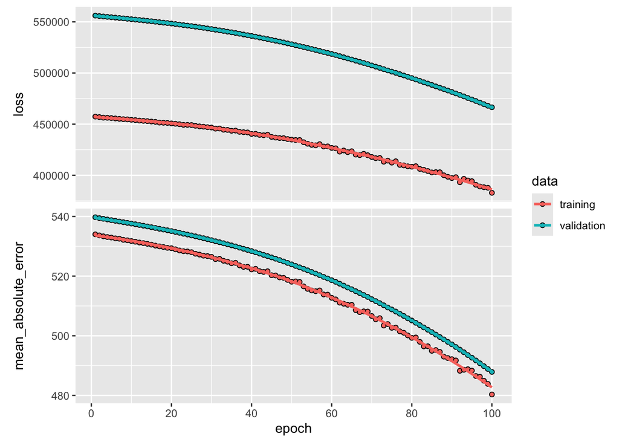

```r
plot(history)
```

Para más información sobre esta función, consulta la página de ayuda de Keras en [RStudio](https://tensorflow.rstudio.com/reference/keras/plot.keras_training_history).

Es importante destacar que si ejecutas el comando fit() por segunda vez en la misma sesión de R, el proceso de ajuste continuará desde donde se quedó. Prueba volver a ejecutar el comando fit() y luego el comando plot() para observarlo.

Finalmente, hacemos predicciones con el modelo final y evaluamos su rendimiento en los datos de prueba. Debido al uso de SGD, los resultados varían ligeramente con cada ajuste. Desafortunadamente, la función set.seed() no garantiza resultados idénticos (ya que el ajuste se realiza en Python), por lo que tus resultados diferirán ligeramente.

```r
npred <- predict(modnn , x[testid , ])
```

```
## 3/3 - 0s - 26ms/step
```

```r
mean(abs(y[testid] - npred))
```

```
## [1] 487.8919
```

# 3 Multi-layer network on MNIST

El paquete keras incluye una serie de conjuntos de datos de ejemplo, entre ellos los datos de dígitos MNIST. Nuestro primer paso es cargar los datos de MNIST. La función dataset_mnist() está disponible para este propósito.

```r
mnist <- dataset_mnist()
str(mnist)
```

```
## List of 2
##  $ train:List of 2
##   ..$ x: int [1:60000, 1:28, 1:28] 0 0 0 0 0 0 0 0 0 0 ...
##   ..$ y: int [1:60000(1d)] 5 0 4 1 9 2 1 3 1 4 ...
##  $ test :List of 2
##   ..$ x: int [1:10000, 1:28, 1:28] 0 0 0 0 0 0 0 0 0 0 ...
##   ..$ y: int [1:10000(1d)] 7 2 1 0 4 1 4 9 5 9 ...
```

```r
x_train <- mnist$train$x
g_train <- mnist$train$y
x_test <- mnist$test$x
g_test <- mnist$test$y
dim(x_train)
```

```
## [1] 60000    28    28
```

```r
dim(x_test)
```

```
## [1] 10000    28    28
```

Hay 60,000 imágenes en los datos de entrenamiento y 10,000 en los datos de prueba. Las imágenes tienen dimensiones $28\times 28$, y se almacenan como un arreglo tridimensional, por lo que necesitamos reestructurarlas en una matriz. Además, debemos codificar en “one-hot” la etiqueta de clase. Afortunadamente, keras incluye muchas funciones integradas para esto.

```r
x_train <- array_reshape(x_train , c(nrow(x_train), 784))
x_test <- array_reshape(x_test, c(nrow(x_test), 784))
y_train <- to_categorical(g_train, 10)
y_test <- to_categorical(g_test, 10)
```

Las redes neuronales son algo sensibles a la escala de las entradas. Por ejemplo, la regularización ridge y lasso se ven afectadas por la escala. Aquí las entradas son valores de escala de grises de 8 bits entre 0 y 255, por lo que reescalamos al intervalo unitario.

```r
x_train <- x_train / 255
x_test <- x_test / 255
```

Ahora estamos listos para ajustar nuestra red neuronal.

```r
modelnn <- keras_model_sequential()
modelnn %>% layer_dense(units = 256, activation = "relu", input_shape = c(784)) %>%
  layer_dropout(rate = 0.4) %>%
  layer_dense(units = 128, activation = "relu") %>%
  layer_dropout(rate = 0.3) %>%
  layer_dense(units = 10, activation = "softmax")
```

La primera capa pasa de $28 \times 28 = 784$ unidades de entrada a una capa oculta de 256 unidades, que utiliza la función de activación ReLU. Esto se especifica con una llamada a layer_dense(), que toma como entrada un objeto modelnn, y devuelve un objeto modelnn modificado. Luego, se pasa a través de layer_dropout() para realizar la regularización dropout. La segunda capa oculta viene a continuación, con 128 unidades ocultas, seguida de una capa dropout. La capa final es la capa de salida, con activación “softmax” (10.13) para el problema de clasificación de 10 clases, que define el mapeo de la segunda capa oculta a probabilidades de clase. Finalmente, usamos summary() para resumir el modelo y asegurarnos de que todo esté correcto.

```r
summary(modelnn)
```

```
## Model: "sequential_1"
## ┏━━━━━━━━━━━━━━━━━━━━━━━━━━━━━━━━━━━┳━━━━━━━━━━━━━━━━━━━━━━━━━━┳━━━━━━━━━━━━━━━┓
## ┃ Layer (type)                      ┃ Output Shape             ┃       Param # ┃
## ┡━━━━━━━━━━━━━━━━━━━━━━━━━━━━━━━━━━━╇━━━━━━━━━━━━━━━━━━━━━━━━━━╇━━━━━━━━━━━━━━━┩
## │ dense_2 (Dense)                   │ (None, 256)              │       200,960 │
## ├───────────────────────────────────┼──────────────────────────┼───────────────┤
## │ dropout_1 (Dropout)               │ (None, 256)              │             0 │
## ├───────────────────────────────────┼──────────────────────────┼───────────────┤
## │ dense_3 (Dense)                   │ (None, 128)              │        32,896 │
## ├───────────────────────────────────┼──────────────────────────┼───────────────┤
## │ dropout_2 (Dropout)               │ (None, 128)              │             0 │
## ├───────────────────────────────────┼──────────────────────────┼───────────────┤
## │ dense_4 (Dense)                   │ (None, 10)               │         1,290 │
## └───────────────────────────────────┴──────────────────────────┴───────────────┘
##  Total params: 235,146 (918.54 KB)
##  Trainable params: 235,146 (918.54 KB)
##  Non-trainable params: 0 (0.00 B)
```

Los parámetros para cada capa incluyen un término de sesgo, lo que resulta en un recuento de parámetros de 235,146. Por ejemplo, la primera capa oculta involucra $(784 + 1) \times 256 = 200,960$ parámetros. Observa que los nombres de las capas, como dropout 1 y dense 2, tienen subíndices. Estos pueden parecer algo aleatorios; de hecho, si ajustas el mismo modelo nuevamente, estos cambiarán. No tienen importancia: varían porque el código de especificación del modelo se ejecuta en Python, y estos subíndices se incrementan cada vez que se llama a keras_model_sequential().

A continuación, agregamos detalles al modelo para especificar el algoritmo de ajuste. Ajustamos el modelo minimizando la función de entropía cruzada.

```r
modelnn %>% compile(loss = "categorical_crossentropy",
                    optimizer = optimizer_rmsprop(),
                    metrics = c("accuracy")
)
```

Ahora estamos listos para continuar. El paso final es proporcionar datos de entrenamiento y ajustar el modelo.

```r
system.time(history <- modelnn %>%
              fit(x_train , y_train , epochs = 50,
                  batch_size = 128, validation_split = 0.2))
```

```
## 375/375 - 3s - 7ms/step - accuracy: 0.8681 - loss: 0.4371 - val_accuracy: 0.9533 - val_loss: 0.1599
## 375/375 - 2s - 6ms/step - accuracy: 0.9394 - loss: 0.2031 - val_accuracy: 0.9654 - val_loss: 0.1219
## 375/375 - 2s - 6ms/step - accuracy: 0.9541 - loss: 0.1548 - val_accuracy: 0.9679 - val_loss: 0.1114
## 375/375 - 2s - 6ms/step - accuracy: 0.9607 - loss: 0.1311 - val_accuracy: 0.9686 - val_loss: 0.1111
## 375/375 - 3s - 7ms/step - accuracy: 0.9657 - loss: 0.1168 - val_accuracy: 0.9738 - val_loss: 0.0887
## 375/375 - 2s - 6ms/step - accuracy: 0.9698 - loss: 0.1014 - val_accuracy: 0.9752 - val_loss: 0.0891
## 375/375 - 3s - 8ms/step - accuracy: 0.9723 - loss: 0.0955 - val_accuracy: 0.9757 - val_loss: 0.0884
## 375/375 - 3s - 8ms/step - accuracy: 0.9740 - loss: 0.0862 - val_accuracy: 0.9768 - val_loss: 0.0919
## 375/375 - 3s - 7ms/step - accuracy: 0.9743 - loss: 0.0818 - val_accuracy: 0.9778 - val_loss: 0.0877
## 375/375 - 3s - 9ms/step - accuracy: 0.9766 - loss: 0.0765 - val_accuracy: 0.9767 - val_loss: 0.0881
## 375/375 - 3s - 9ms/step - accuracy: 0.9765 - loss: 0.0757 - val_accuracy: 0.9783 - val_loss: 0.0868
## 375/375 - 3s - 8ms/step - accuracy: 0.9798 - loss: 0.0667 - val_accuracy: 0.9789 - val_loss: 0.0831
## 375/375 - 3s - 8ms/step - accuracy: 0.9800 - loss: 0.0655 - val_accuracy: 0.9777 - val_loss: 0.0961
## 375/375 - 3s - 9ms/step - accuracy: 0.9814 - loss: 0.0633 - val_accuracy: 0.9778 - val_loss: 0.0929
## 375/375 - 3s - 8ms/step - accuracy: 0.9816 - loss: 0.0634 - val_accuracy: 0.9776 - val_loss: 0.0890
## 375/375 - 3s - 8ms/step - accuracy: 0.9819 - loss: 0.0604 - val_accuracy: 0.9783 - val_loss: 0.0928
## 375/375 - 3s - 9ms/step - accuracy: 0.9829 - loss: 0.0576 - val_accuracy: 0.9784 - val_loss: 0.0853
## 375/375 - 4s - 10ms/step - accuracy: 0.9839 - loss: 0.0532 - val_accuracy: 0.9783 - val_loss: 0.0939
## 375/375 - 3s - 9ms/step - accuracy: 0.9840 - loss: 0.0559 - val_accuracy: 0.9806 - val_loss: 0.0888
## 375/375 - 4s - 11ms/step - accuracy: 0.9835 - loss: 0.0548 - val_accuracy: 0.9791 - val_loss: 0.0932
## 375/375 - 3s - 9ms/step - accuracy: 0.9847 - loss: 0.0515 - val_accuracy: 0.9789 - val_loss: 0.0914
## 375/375 - 3s - 8ms/step - accuracy: 0.9853 - loss: 0.0499 - val_accuracy: 0.9808 - val_loss: 0.0957
## 375/375 - 4s - 10ms/step - accuracy: 0.9846 - loss: 0.0494 - val_accuracy: 0.9802 - val_loss: 0.0954
## 375/375 - 3s - 9ms/step - accuracy: 0.9849 - loss: 0.0503 - val_accuracy: 0.9797 - val_loss: 0.0972
## 375/375 - 3s - 9ms/step - accuracy: 0.9858 - loss: 0.0483 - val_accuracy: 0.9809 - val_loss: 0.0931
## 375/375 - 4s - 10ms/step - accuracy: 0.9857 - loss: 0.0457 - val_accuracy: 0.9803 - val_loss: 0.0947
## 375/375 - 4s - 10ms/step - accuracy: 0.9875 - loss: 0.0427 - val_accuracy: 0.9803 - val_loss: 0.0978
## 375/375 - 4s - 10ms/step - accuracy: 0.9870 - loss: 0.0433 - val_accuracy: 0.9798 - val_loss: 0.1003
## 375/375 - 3s - 8ms/step - accuracy: 0.9870 - loss: 0.0423 - val_accuracy: 0.9804 - val_loss: 0.1068
## 375/375 - 3s - 8ms/step - accuracy: 0.9872 - loss: 0.0434 - val_accuracy: 0.9795 - val_loss: 0.1063
## 375/375 - 3s - 9ms/step - accuracy: 0.9873 - loss: 0.0427 - val_accuracy: 0.9791 - val_loss: 0.1003
## 375/375 - 4s - 10ms/step - accuracy: 0.9884 - loss: 0.0397 - val_accuracy: 0.9803 - val_loss: 0.1028
## 375/375 - 4s - 10ms/step - accuracy: 0.9888 - loss: 0.0378 - val_accuracy: 0.9809 - val_loss: 0.1002
## 375/375 - 4s - 11ms/step - accuracy: 0.9895 - loss: 0.0359 - val_accuracy: 0.9801 - val_loss: 0.1064
## 375/375 - 4s - 10ms/step - accuracy: 0.9889 - loss: 0.0385 - val_accuracy: 0.9809 - val_loss: 0.1044
## 375/375 - 4s - 10ms/step - accuracy: 0.9885 - loss: 0.0388 - val_accuracy: 0.9818 - val_loss: 0.1048
## 375/375 - 4s - 11ms/step - accuracy: 0.9894 - loss: 0.0376 - val_accuracy: 0.9808 - val_loss: 0.1047
## 375/375 - 4s - 11ms/step - accuracy: 0.9888 - loss: 0.0372 - val_accuracy: 0.9816 - val_loss: 0.1064
## 375/375 - 4s - 11ms/step - accuracy: 0.9892 - loss: 0.0372 - val_accuracy: 0.9803 - val_loss: 0.1140
## 375/375 - 3s - 7ms/step - accuracy: 0.9897 - loss: 0.0355 - val_accuracy: 0.9804 - val_loss: 0.1087
## 375/375 - 3s - 8ms/step - accuracy: 0.9897 - loss: 0.0356 - val_accuracy: 0.9809 - val_loss: 0.1060
## 375/375 - 4s - 10ms/step - accuracy: 0.9902 - loss: 0.0340 - val_accuracy: 0.9803 - val_loss: 0.1165
## 375/375 - 4s - 10ms/step - accuracy: 0.9905 - loss: 0.0336 - val_accuracy: 0.9794 - val_loss: 0.1212
## 375/375 - 3s - 8ms/step - accuracy: 0.9900 - loss: 0.0343 - val_accuracy: 0.9815 - val_loss: 0.1169
## 375/375 - 3s - 9ms/step - accuracy: 0.9899 - loss: 0.0333 - val_accuracy: 0.9811 - val_loss: 0.1101
## 375/375 - 4s - 10ms/step - accuracy: 0.9899 - loss: 0.0345 - val_accuracy: 0.9808 - val_loss: 0.1194
## 375/375 - 3s - 9ms/step - accuracy: 0.9895 - loss: 0.0353 - val_accuracy: 0.9809 - val_loss: 0.1155
## 375/375 - 3s - 9ms/step - accuracy: 0.9909 - loss: 0.0312 - val_accuracy: 0.9810 - val_loss: 0.1117
## 375/375 - 4s - 10ms/step - accuracy: 0.9907 - loss: 0.0319 - val_accuracy: 0.9812 - val_loss: 0.1214
## 375/375 - 4s - 10ms/step - accuracy: 0.9901 - loss: 0.0347 - val_accuracy: 0.9815 - val_loss: 0.1180
```

```
##    user  system elapsed
## 225.428 151.799 166.212
```

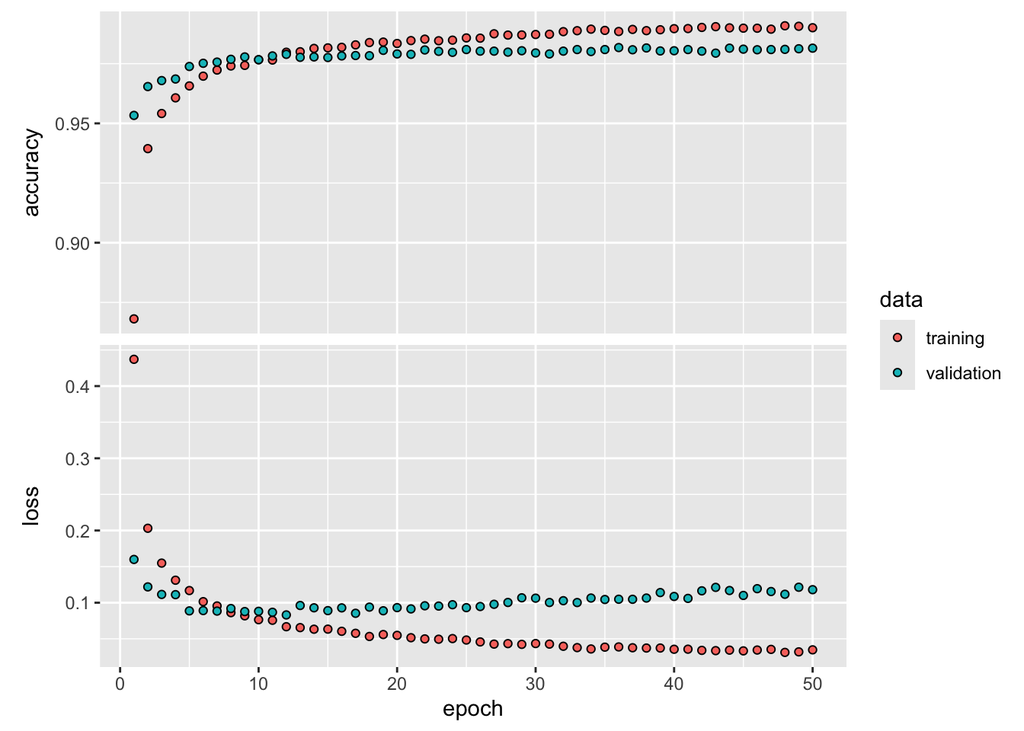

```r
plot(history , smooth = FALSE)
```

Consulta ?fit.keras.engine.training.Model para ver todos los argumentos de ajuste opcionales. SGD utiliza lotes de 128 observaciones para calcular el gradiente, y haciendo los cálculos, vemos que una época corresponde a 375 pasos de gradiente.

Para obtener el error de prueba, simplemente usamos evaluate() de la siguiente manera:

```r
score = evaluate(modelnn,x = x_test,y = y_test)
```

```
## 313/313 - 1s - 2ms/step - accuracy: 0.9820 - loss: 0.1039
```

```r
cat('Test loss:', score$loss, "\n")
```

```
## Test loss: 0.1038593
```

```r
cat('Test accuracy:', score$accuracy, "\n")
```

```
## Test accuracy: 0.982
```

```r
modellr <- keras_model_sequential() %>%
  layer_dense(input_shape = 784, units = 10, activation = "softmax")
summary(modellr)
```

```
## Model: "sequential_2"
## ┏━━━━━━━━━━━━━━━━━━━━━━━━━━━━━━━━━━━┳━━━━━━━━━━━━━━━━━━━━━━━━━━┳━━━━━━━━━━━━━━━┓
## ┃ Layer (type)                      ┃ Output Shape             ┃       Param # ┃
## ┡━━━━━━━━━━━━━━━━━━━━━━━━━━━━━━━━━━━╇━━━━━━━━━━━━━━━━━━━━━━━━━━╇━━━━━━━━━━━━━━━┩
## │ dense_5 (Dense)                   │ (None, 10)               │         7,850 │
## └───────────────────────────────────┴──────────────────────────┴───────────────┘
##  Total params: 7,850 (30.66 KB)
##  Trainable params: 7,850 (30.66 KB)
##  Non-trainable params: 0 (0.00 B)
```

Ajustamos el modelo tal como lo hicimos antes.

```r
modellr %>% compile(loss = "categorical_crossentropy",
                    optimizer = optimizer_rmsprop(), metrics = c("accuracy"))
modellr %>% fit(x_train , y_train , epochs = 30,
                batch_size = 128, validation_split = 0.2)
```

```
## 375/375 - 1s - 3ms/step - accuracy: 0.8351 - loss: 0.6707 - val_accuracy: 0.9040 - val_loss: 0.3597
## 375/375 - 1s - 2ms/step - accuracy: 0.9029 - loss: 0.3528 - val_accuracy: 0.9147 - val_loss: 0.3094
## 375/375 - 1s - 2ms/step - accuracy: 0.9116 - loss: 0.3179 - val_accuracy: 0.9185 - val_loss: 0.2931
## 375/375 - 1s - 2ms/step - accuracy: 0.9162 - loss: 0.3019 - val_accuracy: 0.9226 - val_loss: 0.2840
## 375/375 - 1s - 2ms/step - accuracy: 0.9182 - loss: 0.2921 - val_accuracy: 0.9231 - val_loss: 0.2788
## 375/375 - 1s - 2ms/step - accuracy: 0.9203 - loss: 0.2857 - val_accuracy: 0.9259 - val_loss: 0.2731
## 375/375 - 1s - 2ms/step - accuracy: 0.9213 - loss: 0.2807 - val_accuracy: 0.9246 - val_loss: 0.2720
## 375/375 - 1s - 2ms/step - accuracy: 0.9230 - loss: 0.2766 - val_accuracy: 0.9271 - val_loss: 0.2696
## 375/375 - 1s - 2ms/step - accuracy: 0.9238 - loss: 0.2735 - val_accuracy: 0.9270 - val_loss: 0.2683
## 375/375 - 1s - 2ms/step - accuracy: 0.9249 - loss: 0.2713 - val_accuracy: 0.9274 - val_loss: 0.2669
## 375/375 - 1s - 2ms/step - accuracy: 0.9254 - loss: 0.2687 - val_accuracy: 0.9274 - val_loss: 0.2669
## 375/375 - 1s - 2ms/step - accuracy: 0.9262 - loss: 0.2667 - val_accuracy: 0.9276 - val_loss: 0.2653
## 375/375 - 1s - 2ms/step - accuracy: 0.9268 - loss: 0.2649 - val_accuracy: 0.9287 - val_loss: 0.2657
## 375/375 - 1s - 2ms/step - accuracy: 0.9273 - loss: 0.2634 - val_accuracy: 0.9289 - val_loss: 0.2649
## 375/375 - 1s - 2ms/step - accuracy: 0.9278 - loss: 0.2622 - val_accuracy: 0.9301 - val_loss: 0.2627
## 375/375 - 1s - 2ms/step - accuracy: 0.9281 - loss: 0.2607 - val_accuracy: 0.9295 - val_loss: 0.2621
## 375/375 - 1s - 2ms/step - accuracy: 0.9284 - loss: 0.2594 - val_accuracy: 0.9287 - val_loss: 0.2639
## 375/375 - 1s - 2ms/step - accuracy: 0.9294 - loss: 0.2582 - val_accuracy: 0.9300 - val_loss: 0.2613
## 375/375 - 1s - 2ms/step - accuracy: 0.9294 - loss: 0.2574 - val_accuracy: 0.9304 - val_loss: 0.2635
## 375/375 - 1s - 2ms/step - accuracy: 0.9302 - loss: 0.2563 - val_accuracy: 0.9295 - val_loss: 0.2638
## 375/375 - 1s - 2ms/step - accuracy: 0.9301 - loss: 0.2559 - val_accuracy: 0.9295 - val_loss: 0.2628
## 375/375 - 1s - 2ms/step - accuracy: 0.9299 - loss: 0.2548 - val_accuracy: 0.9296 - val_loss: 0.2623
## 375/375 - 1s - 2ms/step - accuracy: 0.9302 - loss: 0.2540 - val_accuracy: 0.9307 - val_loss: 0.2638
## 375/375 - 1s - 2ms/step - accuracy: 0.9311 - loss: 0.2535 - val_accuracy: 0.9308 - val_loss: 0.2623
## 375/375 - 1s - 2ms/step - accuracy: 0.9308 - loss: 0.2526 - val_accuracy: 0.9308 - val_loss: 0.2619
## 375/375 - 1s - 2ms/step - accuracy: 0.9310 - loss: 0.2519 - val_accuracy: 0.9309 - val_loss: 0.2624
## 375/375 - 1s - 2ms/step - accuracy: 0.9322 - loss: 0.2513 - val_accuracy: 0.9293 - val_loss: 0.2645
## 375/375 - 1s - 2ms/step - accuracy: 0.9315 - loss: 0.2503 - val_accuracy: 0.9314 - val_loss: 0.2624
## 375/375 - 1s - 2ms/step - accuracy: 0.9318 - loss: 0.2501 - val_accuracy: 0.9304 - val_loss: 0.2618
## 375/375 - 1s - 2ms/step - accuracy: 0.9314 - loss: 0.2496 - val_accuracy: 0.9317 - val_loss: 0.2638
```

```r
score = evaluate(modellr,x = x_test,y = y_test)
```

```
## 313/313 - 0s - 1ms/step - accuracy: 0.9272 - loss: 0.2704
```

```r
cat('Test loss:', score$loss, "\n")
```

```
## Test loss: 0.2703991
```

```r
cat('Test accuracy:', score$accuracy, "\n")
```

```
## Test accuracy: 0.9272
```

# 4 Ejercicios

1. Uno de los datasets adicionales, además del MNIST, que vienen directamente con Keras, es el CIFAR 10. Crear una red neuronal para procesar dicho dataset y elaborar un clasificador con un accuracy aceptable, usando una capa oculta de 128 nodos, seguida de una capa de dropout con $p=0.4$, otra capa de 64, también seguida de otra de dropout con el mismo valor para $p$ y una última capa similar, esta vez con 32 nodos. Usar como algoritmo de optimización ADAM.
   - Describe el dataset CIFAR10, ¿cuántas clases tiene? ¿cuál es el tamaño de ejemplo? ¿Qué más detalles del mismo son relevantes para la definición de la ANN?
   - ¿Cuál es el accuracy que se obtiene?
   - ¿Como puedes asegurar de que se ha controlado el overfitting?

# 5 Material complementario

## 5.1 Keras es una API genérica para deep learning

Keras es un wrapper, desarrollado en Python, a varios frameworks de deep learning de bajo nivel, incluyendo TensorFlow (al que está instanciado por defecto), la variante que vamos a trabajar en la asignatura. Pero también puede usarse con Theano (MILA, Univ. Montreal) y CNTK (Microsoft)

El concepto principal en Keras es el de modelo (i.e. nuestra red neuronal). El principal tipo de modelo, y en el que nos vamos a centrar, es el [secuencial](http://keras.io/getting-started/sequential-model-guide/) que se define como una disposición lineal de capas. Para crear un modelo se necesita especificar las capas que va a tener y el orden en el que se disponen.

Procesar por completo un modelo Keras implica:

- Especificar la forma de la entrada al modelo: básicamente cuántos atributos de entrada y el tamaño de los batches que vamos a usar en el entrenamiento.
- Compilar el modelo: se refiere a, primeramente, crear nuestro modelo para dejarlo listo para el entrenamiento. Seguidamente, hay que configurar el proceso de aprendizaje que se va a ejecutar sobre el mismo. Ahí han de especificarse, normalmente, tres elementos: el algoritmo de optimización de los parámetros del modelo, la función de error de la que va a hacer uso el algoritmo de optimización y las métricas a usar para medir el progreso del entrenamiento.
- Entrenar el modelo: mediante la función `fit` invocamos el entrenamiento.

Lo que sigue es un ejemplo de código en Python 2.7 obtenido aquí https://keras.io/getting-started/sequential-model-guide/ en el que se construye una red, con Keras, de 100 entradas (`input_dim`), con batches de 32 samples y activación ReLU (Rectified Linear Unit) https://en.wikipedia.org/wiki/Rectifier_(neural_networks). La segunda capa aplica una sigmoide a la salida, el algoritmo backpropagation con una variante que modifica el learning rate conforme se avanza en el aprendizaje.

```python
model = Sequential()
model.add(Dense(32, activation='relu', input_dim=100))
model.add(Dense(1, activation='sigmoid'))
model.compile(optimizer='rmsprop',
              loss='binary_crossentropy',
              metrics=['accuracy'])
```

La función de error, para el caso de dos nodos de salida, es la de entropía cruzada, tal que

$$V(f(x),t) =
-t ln(f(x)) - (1-t) ln(1 - f(x)),$$
siendo $t=(1+y)/2$ para que el valor de t esté en $[0,1]$. La forma general de dicha función es
$$H(y) = - \sum_{i} y'_{i}
log(y_i),$$
en donde $y$ es la distribución de probabilidad predicha por la red (ver abajo) e $y'$ la distribución correcta (i.e. la correspondiente a la etiqueta de clase del ejemplar correspondiente).

Una vez que nuestro modelo está configurado, generamos un conjunto de datos aleatorio, de 1000 ejemplares y 100 predictores. Para las etiquetas generamos las correspondientes a un problema binaro. Posteriormente, invocamos a `model.fit` con 10 epochs y un tamaño de batch de 32 ejemplares cada vez.

```python
# Generate dummy data
import numpy as np
data = np.random.random((1000, 100))
labels = np.random.randint(2, size=(1000, 1))

# Train the model, iterating on the data in batches of 32 samples
model.fit(data, labels, epochs=10, batch_size=32)
```

Este ejemplo tiene el objetivo simple de mostrar que Python es el lenguaje nativo para Keras, nada más. El resto de material se basa en acceso a Keras mediante R.

## 5.2 KERAS puede usarse desde R de manera sencilla

Keras es una API que puede integrar diferentes motores de deep learning, entre ellos TensorFlow (TF). TF está programado en C++ y Python; Keras es 100% Python pero incorpora Wrappers que lo hacen accesible a otros lenguajes, por ejemplo R. Como nuestro objetivo no es aprender otro lenguaje, que posiblemente ya conoces, vamos a usar Keras desde R; aunque para nosotros todo esto, como usuarios, es transparente.

## 5.3 La instalación incluye Python y tensorflow

En pocos pasos vamos a explicar cómo instalar (1) lo necesario para cálculo científico con Python, (2) el framework de TensorFlow para deep learning y (3) Keras para uso de TensorFlow, en base a `pip` y (4) la instalación de R Keras desde RStudio.

Se aconseja usar Linux o Mac aunque también sería posible hacerlo funcionar en Windows, pero esa parte no la documentamos.

### 5.3.1 Instalación fácil

En principio, la instalación más sencilla de todo lo que necesitamos se reduce tres comandos, que podemos consultar en https://keras.rstudio.com/

```r
devtools::install_github("rstudio/keras")
reticulate:: install_python(version="3.10")
tensorflow::install_tensorflow()
```

### 5.3.2 Si TensorFlow no se ha instalado correctamente

Si la instalación de TF, que debería haber ocurrido después de ésto automáticamente, te da algún problema, puedes intentar instalarlo tú mismo. En principio, **es tan sencillo como hacer lo siguiente desde una consola linux**:

```bash
sudo easy_install pip
sudo pip install --upgrade virtualenv
virtualenv --system-site-packages -p python3 ~/tensorflow/
```

Nótese que hemos hecho una instalación basada en un entorno virtual. La idea del entorno virtual es la de crear un sistema Python al completo de tal forma que cada environment se corresponde con una versión particular de Python, una lista de paquetes particular instalada y sus correspondientes versiones para que todo funcione de manera exclusiva para una tarea concreta (e.g. deep learning). En este caso, hemos instalado un environment artificial denominado `tensorflow` en nuestro directorio raíz basado en la versión 3 de Python.

Si es la primera vez usas Python para cálculo científico, tendrás que instalar estos paquetes en el `venvironment` que acabamos de crear

```bash
cd; cd tensorflow/bin;
./pip install --user numpy scipy matplotlib ipython jupyter pandas sympy nose
./pip install -U scikit-learn
```

Una vez hemos hecho eso, y para asegurarnos de que nuestro RStudio usa el environment que acabamos de instalar, hacemos uso de la función `reticulate::use_virtualenv` como sigue

```r
library(reticulate)
use_virtualenv("~/tensorflow/")
```

y, tras esto, ya podemos instalar desde R el correspondiente Wrapper a TensorFlow.

```r
install.packages("tensorflow")
library(tensorflow)
install_tensorflow()
```

Y en principio debería estar listo.